# CS236781: Deep Learning on Computational Accelerators

### Generating text by sampling

Now that we have a model, we can implement **text generation** based on it. The idea is simple: At each timestep our model receives one char $x_t$ from the input sequence and outputs scores $y_t$ for what the next char should be. We'll convert these scores into a probability over each of the possible chars. In other words, for each input char $x_t$ we create a probability distribution for the next char conditioned on the current one and the state of the model (representing all previous inputs): $$p(x_{t+1}|x_t, \vec{h}_t).$$

Once we have such a distribution, we'll sample a char from it. This will be the first char of our generated sequence. Now we can feed this new char into the model, create another distribution, sample the next char and so on. Note that it's crucial to propagate the hidden state when sampling.

The important point however is how to create the distribution from the scores. One way, as we saw in previous ML tasks, is to use the softmax function. However, a drawback of softmax is that it can generate very diffuse (more uniform) distributions if the score values are very similar. When sampling, we would prefer to control the distributions and make them less uniform to increase the chance of sampling the char(s) with the highest scores compared to the others.

To control the variance of the distribution, a common trick is to add a hyperparameter $T$, known as the *temperature* to the softmax function. The class scores are simply scaled by $T$ before softmax is applied: $$ \mathrm{softmax}_T(\vec{y}) = \frac{e^{\vec{y}/T}}{\sum_k e^{y_k/T}} $$

A low $T$ will result in less uniform distributions and vice-versa.

**TODO**: Implement the `hot_softmax()` function in the `hw3/charnn.py` module.

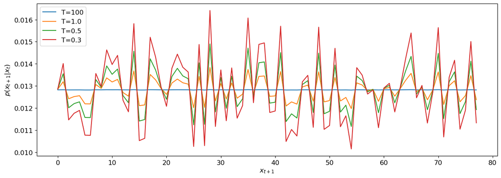

```python
scores = y[0,0,:].detach()
_, ax = plt.subplots(figsize=(15,5))

for t in reversed([0.3, 0.5, 1.0, 100]):
    ax.plot(charnn.hot_softmax(scores, temperature=t).cpu().numpy(), label=f'T={t}')
ax.set_xlabel('$x_{t+1}$')
ax.set_ylabel('$p(x_{t+1}|x_t)$')
ax.legend()

uniform_proba = 1/len(char_to_idx)
uniform_diff = torch.abs(charnn.hot_softmax(scores, temperature=100) - uniform_proba)
test.assertTrue(torch.all(uniform_diff < 1e-4))
```

**TODO**: Implement the `generate_from_model()` function in the `hw3/charnn.py` module.

```python
for _ in range(3):
    text = charnn.generate_from_model(model, "foobar", 50, (char_to_idx, idx_to_char), T=0.5)
    print(text)
    test.assertEqual(len(text), 50)
```

```
foobarZ]:gsN[Ge;VSndAQ,IfIkYFitAOYZDyEG2hjEncsjp)9
foobarORg3hPYxZJR Ei'(FM2p[p]hv6L5CT7I&Y-enyjNjLfE
foobar:'jrR6jxe.PpWQG(.nWa"ja7R7fQK6,uWOQzoLxhxGV,
```

### Training

To train this model, we'll calculate the loss at each time step by comparing the predicted char to the actual char from our label. We can use cross entropy since per char it's similar to a classification problem. We'll then sum the losses over the sequence and back-propagate the gradients though time. Notice that the back-propagation algorithm will "visit" each layer's parameter tensors multiple times, so we'll accumulate gradients in parameters of the blocks. Luckily `autograd` will handle this part for us.

As usual, the first step of training will be to try and **overfit** a large model (many parameters) to a tiny dataset. Again, this is to ensure the model and training code are implemented correctly, i.e. that the model can learn.

For a generative model such as this, overfitting is slightly trickier than for classification. What we'll aim to do is to get our model to **memorize** a specific sequence of chars, so that when given the first char in the sequence it will immediately spit out the rest of the sequence verbatim.

Let's create a tiny dataset to memorize.

```python
# Pick a tiny subset of the dataset
subset_start, subset_end = 1001, 1005
ds_corpus_ss = torch.utils.data.Subset(ds_corpus, range(subset_start, subset_end))
batch_size_ss = 1
sampler_ss = SequenceBatchSampler(ds_corpus_ss, batch_size=batch_size_ss)
dl_corpus_ss = torch.utils.data.DataLoader(ds_corpus_ss, batch_size_ss, sampler=sampler_ss, shuffle=False)

# Convert subset to text
subset_text = ''
for i in range(subset_end - subset_start):
    subset_text += unembed(ds_corpus_ss[i][0])
print(f'Text to "memorize":\n\n{subset_text}')
```

```
Text to "memorize":

TRAM. What would you have?
  HELENA. Something; and scarce so much; nothing, indeed.
    I would not tell you what I would, my lord.
    Faith, yes:
    Strangers and foes do sunder and not kiss.
  BERTRAM. I pray you, stay not, but in haste to horse.
  HE
```

Now let's implement the first part of our training code.

**TODO**: Implement the `train_epoch()` and `train_batch()` methods of the `RNNTrainer` class in the `hw3/training.py` module. You must think about how to correctly handle the hidden state of the model between batches and epochs for this specific task (i.e. text generation).

```python
import torch.nn as nn
import torch.optim as optim
from hw3.training import RNNTrainer

torch.manual_seed(42)

lr = 0.01
num_epochs = 500

in_dim = vocab_len
h_dim = 128
n_layers = 2
loss_fn = nn.CrossEntropyLoss()
model = charnn.MultilayerGRU(in_dim, h_dim, out_dim=in_dim, n_layers=n_layers).to(device)
optimizer = optim.Adam(model.parameters(), lr=lr)
trainer = RNNTrainer(model, loss_fn, optimizer, device)

for epoch in range(num_epochs):
    epoch_result = trainer.train_epoch(dl_corpus_ss, verbose=False)

    # Every X epochs, we'll generate a sequence starting from the first char in the first sequence
    # to visualize how/if/what the model is learning.
    if epoch == 0 or (epoch+1) % 25 == 0:
        avg_loss = np.mean(epoch_result.losses)
        accuracy = np.mean(epoch_result.accuracy)
        print(f'\nEpoch #{epoch+1}: Avg. loss = {avg_loss:.3f}, Accuracy = {accuracy:.2f}%')

        generated_sequence = charnn.generate_from_model(model, subset_text[0],
                                                        seq_len*(subset_end-subset_start),
                                                        (char_to_idx,idx_to_char), T=0.1)

        # Stop if we've successfully memorized the small dataset.
        print(generated_sequence)
        if generated_sequence == subset_text:
            break

# Test successful overfitting
test.assertGreater(epoch_result.accuracy, 99)
test.assertEqual(generated_sequence, subset_text)
```

```
Epoch #1: Avg. loss = 3.954, Accuracy = 18.36%
Tt

Epoch #25: Avg. loss = 0.667, Accuracy = 82.81%
TAM. What would you have?
  HELENA. Something, indeed.
    I would not would not hat horse.
   I would not indhe s and nothing, indee nothing, indee nothing, indee nothing, indee nothing, indee nothing, indeed.
    I would not ind, ny not, indee nothing, i

Epoch #50: Avg. loss = 0.020, Accuracy = 100.00%
TRAM. What would you have?
  HELENA. Something; and scarce so much; nothing, indeed.
    I would not tell you what I would, my lord.
    Faith, yes:
    Strangers and foes do sunder and not kiss.
  BERTRAM. I pray you, stay not, but in haste to horse.
  HE
```

OK, so training works - we can memorize a short sequence. We'll now train a much larger model on our large dataset. You'll need a GPU for this part.

First, lets set up our dataset and models for training. We'll split our corpus into 90% train and 10% test-set. Also, we'll use a learning-rate scheduler to control the learning rate during training.

**TODO**: Set the hyperparameters in the `part1_rnn_hyperparams()` function of the `hw3/answers.py` module.

```python
from hw3.answers import part1_rnn_hyperparams

hp = part1_rnn_hyperparams()
print('hyperparams:\n', hp)

### Dataset definition
vocab_len = len(char_to_idx)
batch_size = hp['batch_size']
seq_len = hp['seq_len']
train_test_ratio = 0.9
num_samples = (len(corpus) - 1) // seq_len
num_train = int(train_test_ratio * num_samples)

samples, labels = charnn.chars_to_labelled_samples(corpus, char_to_idx, seq_len, device)

ds_train = torch.utils.data.TensorDataset(samples[:num_train], labels[:num_train])
sampler_train = SequenceBatchSampler(ds_train, batch_size)
dl_train = torch.utils.data.DataLoader(ds_train, batch_size, shuffle=False, sampler=sampler_train, drop_last=True)

ds_test = torch.utils.data.TensorDataset(samples[num_train:], labels[num_train:])
sampler_test = SequenceBatchSampler(ds_test, batch_size)
dl_test = torch.utils.data.DataLoader(ds_test, batch_size, shuffle=False, sampler=sampler_test, drop_last=True)

print(f'Train: {len(dl_train):3d} batches, {len(dl_train)*batch_size*seq_len:7d} chars')
print(f'Test:  {len(dl_test):3d} batches, {len(dl_test)*batch_size*seq_len:7d} chars')

### Training definition
in_dim = out_dim = vocab_len
checkpoint_file = 'checkpoints/rnn'
num_epochs = 50
early_stopping = 5

model = charnn.MultilayerGRU(in_dim, hp['h_dim'], out_dim, hp['n_layers'], hp['dropout'])
loss_fn = nn.CrossEntropyLoss()
optimizer = optim.Adam(model.parameters(), lr=hp['learn_rate'])
scheduler = optim.lr_scheduler.ReduceLROnPlateau(
    optimizer, mode='max', factor=hp['lr_sched_factor'], patience=hp['lr_sched_patience'], verbose=True
)
trainer = RNNTrainer(model, loss_fn, optimizer, device)
```

```
hyperparams:
 {'batch_size': 256, 'seq_len': 64, 'h_dim': 512, 'n_layers': 2, 'dropout': 0.3, 'learn_rate': 0.001, 'lr_sched_factor': 0.45, 'lr_sched_patience': 3}
Train: 348 batches, 5701632 chars
Test:   38 batches,  622592 chars
```

The code blocks below will train the model and save checkpoints containing the training state and the best model parameters to a file. This allows you to stop training and resume it later from where you left.

Note that you can use the `main.py` script provided within the assignment folder to run this notebook from the command line as if it were a python script by using the `run-nb` subcommand. This allows you to train your model using this notebook without starting jupyter. You can combine this with `srun` or `sbatch` to run the notebook with a GPU on the course servers.

**TODO**:

- Implement the `fit()` method of the `Trainer` class. You can reuse the relevant implementation parts from HW2, but make sure to implement early stopping and checkpoints.
- Implement the `test_epoch()` and `test_batch()` methods of the `RNNTrainer` class in the `hw3/training.py` module.
- Run the following block to train.
- When training is done and you're satisfied with the model's outputs, rename the checkpoint file to `checkpoints/rnn_final.pt`. This will cause the block to skip training and instead load your saved model when running the homework submission script. Note that your submission zip file will not include the checkpoint file. This is OK.

```python
from cs236781.plot import plot_fit

def post_epoch_fn(epoch, train_res, test_res, verbose):
    # Update learning rate
    scheduler.step(test_res.accuracy)
    # Sample from model to show progress
    if verbose:
        start_seq = "ACT I."
        generated_sequence = charnn.generate_from_model(
            model, start_seq, 100, (char_to_idx,idx_to_char), T=0.5
        )
        print(generated_sequence)

# Train, unless final checkpoint is found
checkpoint_file_final = f'{checkpoint_file}_final.pt'
if os.path.isfile(checkpoint_file_final):
    print(f'*** Loading final checkpoint file {checkpoint_file_final} instead of training')
    saved_state = torch.load(checkpoint_file_final, map_location=device)
    model.load_state_dict(saved_state['model_state'])
else:
    try:
        # Print pre-training sampling
        print(charnn.generate_from_model(model, "ACT I.", 100, (char_to_idx,idx_to_char), T=0.5))

        fit_res = trainer.fit(dl_train, dl_test, num_epochs, max_batches=None,
                                  post_epoch_fn=post_epoch_fn, early_stopping=early_stopping,
                              checkpoints=checkpoint_file, print_every=1)

        fig, axes = plot_fit(fit_res)
    except KeyboardInterrupt as e:
        print('\n *** Training interrupted by user')
```

```
*** Loading final checkpoint file checkpoints/rnn_final.pt instead of training
```

### Generating a work of art

Armed with our fully trained model, let's generate the next Hamlet! You should experiment with modifying the sampling temperature and see what happens.

The text you generate should “look” like a Shakespeare play: old-style English words and sentence structure, directions for the actors (like “Exit/Enter”), sections (Act I/Scene III) etc. There will be no coherent plot of course, but it should at least seem like a Shakespearean play when not looking too closely. If this is not what you see, go back, debug and/or and re-train.

**TODO**: Specify the generation parameters in the `part1_generation_params()` function within the `hw3/answers.py` module.

```python
from hw3.answers import part1_generation_params

start_seq, temperature = part1_generation_params()

generated_sequence = charnn.generate_from_model(
    model, start_seq, 10000, (char_to_idx,idx_to_char), T=temperature
)

print(generated_sequence)
```

```
ACT I.
ANTIPHOLUS OF SYRACUSE. An honourable tent, and shall not do thee,
    us by the first courtiers of her body to the heart, and
    for a jewel of thy brother, and the empression of the
    fellow of my sister.
  STEPHANO. Never I dare to thee, if thou wert a grace and come to the
    tenth of a fooliar mother. I have heard of him that I must not
    think I do not spend my man and our grave better poor and so long
    and my son cannot come in the poor part.
  ANTONY. The great commanders the army be a man.
    Three times have lead the sleeves of me.
  CLEOPATRA. I am no further.
  SEBASTIAN. O helan!
  DUCHESS. What ho! I have been all our names when there
    Is well according to the house of York.
  DUCHESS. What done, my lord?
  QUEEN ELIZABETH. No, by my soul!
    What is the matter? The sun did not have done,
    That the consent of the profane of the day,
    When he shall see the wind and heart the shadow.
  KING EDWARD. Many the man is borne in his defeat,
    And the devil hath had a counterfeit state
    To the profession of my sword with that.
    I'll attend it for a beggar's love in spite.
    What is the cat the courage of the house?
    And what have I my power in this true script?
    If he have bated me, this hour is dead.
    But heaven his honour in her heart deceives
    The country's death, and the which should have scorn'd him.
    And so shall I say wheth he would not come.
    Heartily and we are well advis'd.
                                                             Exeunt

SCENE 2.

London. The palace

Enter the LUCENTIO as the COURT'S in AND INE

  ANGELO. What have you with him?
```

[output cut: 175 more lines]

```
    And the sweet man of this my mother shood.
    What say you to your Harry when on heart
    I have been grievously in Rome an hour
    To him that you have the belly and the article
    Of the fair mild and fire of her eyes have shook
    He would begin and hide him, here at heart,
    And then I came unto the cradle of the matter.
  JULIA. And so is this; 'twere no convenient lord;
    The blood of his conceusion do not know
    The enemy will follow him with all our cousins,
    The like a word with you; and he's a show,
    Of this great part whereof the sun of blood
    Was the compassion of the charge of hell.
    But when the point of nature is a flatterer,
    Consent to make me hear the second
```

## Questions

**TODO** Answer the following questions. Write your answers in the appropriate variables in the module `hw3/answers.py`.

```python
from cs236781.answers import display_answer
import hw3.answers
```

### Question 1

Why do we split the corpus into sequences instead of training on the whole text?

```python
display_answer(hw3.answers.part1_q1)
```

We want to split the corpus during the training for multiples reasons: First, we want the model to use only the recent data intake to predict future characters, as words appearing a lot before shouldn't affect our prediction that much. Second, splitting the corpus into sequences makes it possible to upload examples to memory of reasonable size, the whole corpus would take all the available memory.

### Question 2

How is it possible that the generated text clearly shows memory longer than the sequence length?

```python
display_answer(hw3.answers.part1_q2)
```

It's possible because the memory used to generate text comes from multiple sources - the previous generated text, in addition to the model's hidden state - meaning the final output isn't just limited by the previous sequence max length. This is why it's possible for the hidden state to capture more memory than the sequence length, providing us with a longer than max length generated text.

### Question 3

Why are we not shuffling the order of batches when training?

```python
display_answer(hw3.answers.part1_q3)
```

We are not shuffling the sequences because their order is important. Indeed, when going through the corpus batches, we see that current outputs rely on previous batches with text that composes sentences together.

### Question 4

1. Why do we lower the temperature for sampling (compared to the default of $1.0$)?
2. What happens when the temperature is very high and why?
3. What happens when the temperature is very low and why?

```python
display_answer(hw3.answers.part1_q4)
```

**Your answer:**

2. When the temp is very high, the variance of the output distribution will be very high - meaning that no output will stand out and the outputs will be in a uniform distribution.

3. When the temp is very low, we get a very low variance - meaning that high score outputs will stand out much more clearly.

$$ \newcommand{\mat}[1]{\boldsymbol {#1}} \newcommand{\mattr}[1]{\boldsymbol {#1}^\top} \newcommand{\matinv}[1]{\boldsymbol {#1}^{-1}} \newcommand{\vec}[1]{\boldsymbol {#1}} \newcommand{\vectr}[1]{\boldsymbol {#1}^\top} \newcommand{\rvar}[1]{\mathrm {#1}} \newcommand{\rvec}[1]{\boldsymbol{\mathrm{#1}}} \newcommand{\diag}{\mathop{\mathrm {diag}}} \newcommand{\set}[1]{\mathbb {#1}} \newcommand{\norm}[1]{\left\lVert#1\right\rVert} \newcommand{\pderiv}[2]{\frac{\partial #1}{\partial #2}} \newcommand{\bm}[1]{{\bf #1}} \newcommand{\bb}[1]{\bm{\mathrm{#1}}} $$

# Part 2: Variational Autoencoder

In this part we will learn to generate new data using a special type of autoencoder model which allows us to sample from its latent space. We'll implement and train a VAE and use it to generate new images.

```python
import unittest
import os
import sys
import pathlib
import urllib
import shutil
import re
import zipfile

import numpy as np
import torch
import matplotlib.pyplot as plt

%load_ext autoreload
%autoreload 2
```

```python
test = unittest.TestCase()
plt.rcParams.update({'font.size': 12})
device = torch.device('cuda' if torch.cuda.is_available() else 'cpu')
print('Using device:', device)
```

```
Using device: cpu
```

### Obtaining the dataset

Let's begin by downloading a dataset of images that we want to learn to generate. We'll use the [Labeled Faces in the Wild](http://vis-www.cs.umass.edu/lfw/) (LFW) dataset which contains many labeled faces of famous individuals.

We're going to train our generative model to generate a specific face, not just any face. Since the person with the most images in this dataset is former president George W. Bush, we'll set out to train a Bush Generator :)

However, if you feel adventurous and/or prefer to generate something else, feel free to edit the `PART2_CUSTOM_DATA_URL` variable in `hw3/answers.py`.

```python
import cs236781.plot as plot
import cs236781.download
from hw3.answers import PART2_CUSTOM_DATA_URL as CUSTOM_DATA_URL

DATA_DIR = pathlib.Path.home().joinpath('.pytorch-datasets')
if CUSTOM_DATA_URL is None:
    DATA_URL = 'http://vis-www.cs.umass.edu/lfw/lfw-bush.zip'
else:
    DATA_URL = CUSTOM_DATA_URL

_, dataset_dir = cs236781.download.download_data(out_path=DATA_DIR, url=DATA_URL, extract=True, force=False)
```

```
File C:\Users\HAGIL\.pytorch-datasets\lfw-bush.zip exists, skipping download.
Extracting C:\Users\HAGIL\.pytorch-datasets\lfw-bush.zip...
Extracted 531 to C:\Users\HAGIL\.pytorch-datasets\lfw/George_W_Bush
```

Create a `Dataset` object that will load the extraced images:

```python
import torchvision.transforms as T
from torchvision.datasets import ImageFolder

im_size = 64
tf = T.Compose([
    # Resize to constant spatial dimensions
    T.Resize((im_size, im_size)),
    # PIL.Image -> torch.Tensor
    T.ToTensor(),
    # Dynamic range [0,1] -> [-1, 1]
    T.Normalize(mean=(.5,.5,.5), std=(.5,.5,.5)),
])

ds_gwb = ImageFolder(os.path.dirname(dataset_dir), tf)
```

OK, let's see what we got. You can run the following block multiple times to display a random subset of images from the dataset.

```
Found 530 images in dataset folder.
```

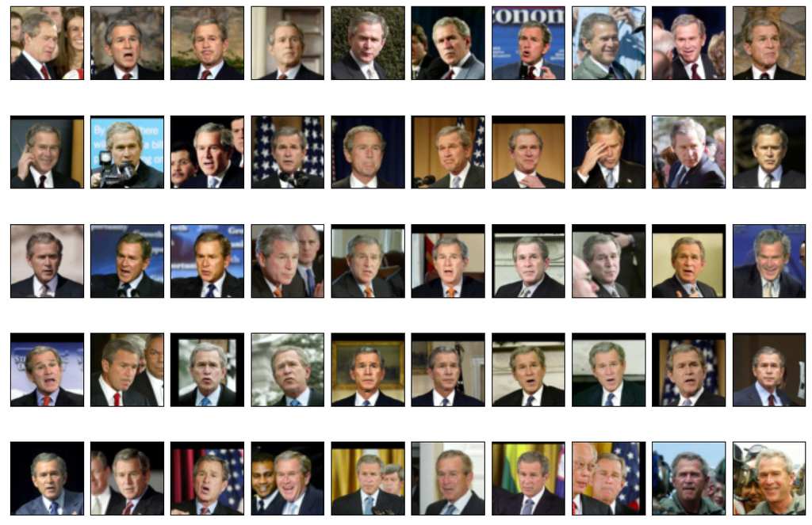

```python
_ = plot.dataset_first_n(ds_gwb, 50, figsize=(15,10), nrows=5)
print(f'Found {len(ds_gwb)} images in dataset folder.')
```

```python
x0, y0 = ds_gwb[0]
x0 = x0.unsqueeze(0).to(device)
print(x0.shape)

test.assertSequenceEqual(x0.shape, (1, 3, im_size, im_size))
```

```
torch.Size([1, 3, 64, 64])
```

## The Variational Autoencoder

An autoencoder is a model which learns a representation of data in an **unsupervised** fashion (i.e without any labels). Recall it's general form from the lecture:

[figure not shown]

An autoencoder maps an instance $\bb{x}$ to a **latent-space** representation $\bb{z}$. It has an encoder part, $\Phi_{\bb{\alpha}}(\bb{x})$ (a model with parameters $\bb{\alpha}$) and a decoder part, $\Psi_{\bb{\beta}}(\bb{z})$ (a model with parameters $\bb{\beta}$).

While autoencoders can learn useful representations, generally it's hard to use them as generative models because there's no distribution we can sample from in the latent space. In other words, we have no way to choose a point $\bb{z}$ in the latent space such that $\Psi(\bb{z})$ will end up on the data manifold in the instance space.

[figure not shown]

The variational autoencoder (VAE), first proposed by [Kingma and Welling](https://arxiv.org/pdf/1312.6114.pdf), addresses this issue by taking a probabilistic perspective. Briefly, a VAE model can be described as follows.

We define, in Baysean terminology,

- The **prior** distribution $p(\bb{Z})$ on points in the latent space.
- The **posterior** distribution of points in the latent spaces given a specific instance: $p(\bb{Z}|\bb{X})$.
- The **likelihood** distribution of a sample $\bb{X}$ given a latent-space representation: $p(\bb{X}|\bb{Z})$.
- The **evidence** distribution $p(\bb{X})$ which is the distribution of the instance space due to the generative process.

To create our variational **decoder** we'll further specify:

- A parametric likelihood distribution, $p _{\bb{\beta}}(\bb{X} | \bb{Z}=\bb{z}) = \mathcal{N}( \Psi _{\bb{\beta}}(\bb{z}) , \sigma^2 \bb{I} )$. The interpretation is that given a latent $\bb{z}$, we map it to a point normally distributed around the point calculated by our decoder neural network. Note that here $\sigma^2$ is a hyperparameter while $\vec{\beta}$ represents the network parameters.
- A fixed latent-space prior distribution of $p(\bb{Z}) = \mathcal{N}(\bb{0},\bb{I})$.

This setting allows us to generate a new instance $\bb{x}$ by sampling $\bb{z}$ from the multivariate normal distribution, obtaining the instance-space mean $\Psi _{\bb{\beta}}(\bb{z})$ using our decoder network, and then sampling $\bb{x}$ from $\mathcal{N}( \Psi _{\bb{\beta}}(\bb{z}) , \sigma^2 \bb{I} )$.

Our variational **encoder** will approximate the posterior with a parametric distribution $q _{\bb{\alpha}}(\bb{Z} | \bb{x}) = \mathcal{N}( \bb{\mu} _{\bb{\alpha}}(\bb{x}), \mathrm{diag}\{ \bb{\sigma}^2_{\bb{\alpha}}(\bb{x}) \} )$. The interpretation is that our encoder model, $\Phi_{\vec{\alpha}}(\bb{x})$, calculates the mean and variance of the posterior distribution, and samples $\bb{z}$ based on them. An important nuance here is that our network can't contain any stochastic elements that depend on the model parameters, otherwise we won't be able to back-propagate to those parameters. So sampling $\bb{z}$ from $\mathcal{N}( \bb{\mu} _{\bb{\alpha}}(\bb{x}), \mathrm{diag}\{ \bb{\sigma}^2_{\bb{\alpha}}(\bb{x}) \} )$ is not an option. The solution is to use what's known as the **reparametrization trick**: sample from an isotropic Gaussian, i.e. $\bb{u}\sim\mathcal{N}(\bb{0},\bb{I})$ (which doesn't depend on trainable parameters), and calculate the latent representation as $\bb{z} = \bb{\mu} _{\bb{\alpha}}(\bb{x}) + \bb{u}\odot\bb{\sigma}_{\bb{\alpha}}(\bb{x})$.

To train a VAE model, we maximize the evidence distribution, $p(\bb{X})$ (see question below). The **VAE loss** can therefore be stated as minimizing $\mathcal{L} = -\mathbb{E}_{\bb{x}} \log p(\bb{X})$. Although this expectation is intractable, we can obtain a lower-bound for $p(\bb{X})$ (the evidence lower bound, "ELBO", shown in the lecture):

$$ \log p(\bb{X}) \ge \mathbb{E} _{\bb{z} \sim q _{\bb{\alpha}} }\left[ \log p _{\bb{\beta}}(\bb{X} | \bb{z}) \right] - \mathcal{D} _{\mathrm{KL}}\left(q _{\bb{\alpha}}(\bb{Z} | \bb{X})\,\left\|\, p(\bb{Z} )\right.\right) $$

where $ \mathcal{D} _{\mathrm{KL}}(q\left\|\right.p) = \mathbb{E}_{\bb{z}\sim q}\left[ \log \frac{q(\bb{Z})}{p(\bb{Z})} \right] $ is the Kullback-Liebler divergence, which can be interpreted as the information gained by using the posterior $q(\bb{Z|X})$ instead of the prior distribution $p(\bb{Z})$.

By remembering that the likelihood is a Gaussian distribution with a diagonal covariance and by applying the reparametrization trick, we can write the above as

$$ \mathcal{L}(\vec{\alpha},\vec{\beta}) = \mathbb{E} _{\bb{x}} \left[ \mathbb{E} _{\bb{z} \sim q _{\bb{\alpha}} } \left[ \frac{1}{2\sigma^2}\left\| \bb{x}- \Psi _{\bb{\beta}}\left( \bb{\mu} _{\bb{\alpha}}(\bb{x}) + \bb{\Sigma}^{\frac{1}{2}} _{\bb{\alpha}}(\bb{x}) \bb{u} \right) \right\| _2^2 \right] + \mathcal{D} _{\mathrm{KL}}\left(q _{\bb{\alpha}}(\bb{Z} | \bb{x})\,\left\|\, p(\bb{Z} )\right.\right) \right]. $$

### Model Implementation

Obviously our model will have two parts, an encoder and a decoder. Since we're working with images, we'll implement both as deep **convolutional** networks, where the decoder is a "mirror image" of the encoder implemented with adjoint (AKA transposed) convolutions. Between the encoder CNN and the decoder CNN we'll implement the sampling from the parametric posterior approximator $q_{\bb{\alpha}}(\bb{Z}|\bb{x})$ to make it a VAE model and not just a regular autoencoder (of course, this is not yet enough to create a VAE, since we also need a special loss function which we'll get to later).

First let's implement just the CNN part of the Encoder network (this is not the full $\Phi_{\vec{\alpha}}(\bb{x})$ yet). As usual, it should take an input image and map to a activation volume of a specified depth. We'll consider this volume as the features we extract from the input image. Later we'll use these to create the latent space representation of the input.

**TODO**: Implement the `EncoderCNN` class in the `hw3/autoencoder.py` module. Implement any CNN architecture you like. If you need "architecture inspiration" you can see e.g. [this](https://arxiv.org/pdf/1512.09300.pdf) or [this](https://arxiv.org/pdf/1511.06434.pdf) paper.

```python
import hw3.autoencoder as autoencoder

in_channels = 3
out_channels = 1024
encoder_cnn = autoencoder.EncoderCNN(in_channels, out_channels).to(device)
print(encoder_cnn)

h = encoder_cnn(x0)
print(h.shape)

test.assertEqual(h.dim(), 4)
test.assertSequenceEqual(h.shape[0:2], (1, out_channels))
```

```
EncoderCNN(
  (cnn): Sequential(
    (0): Conv2d(3, 64, kernel_size=(5, 5), stride=(1, 1), padding=(2, 2), bias=False)
    (1): MaxPool2d(kernel_size=2, stride=2, padding=0, dilation=1, ceil_mode=False)
    (2): BatchNorm2d(64, eps=1e-05, momentum=0.1, affine=True, track_running_stats=True)
    (3): GELU()
    (4): Conv2d(64, 128, kernel_size=(5, 5), stride=(1, 1), padding=(2, 2), bias=False)
    (5): MaxPool2d(kernel_size=2, stride=2, padding=0, dilation=1, ceil_mode=False)
    (6): BatchNorm2d(128, eps=1e-05, momentum=0.1, affine=True, track_running_stats=True)
    (7): GELU()
    (8): Conv2d(128, 256, kernel_size=(5, 5), stride=(1, 1), padding=(2, 2), bias=False)
    (9): MaxPool2d(kernel_size=2, stride=2, padding=0, dilation=1, ceil_mode=False)
    (10): BatchNorm2d(256, eps=1e-05, momentum=0.1, affine=True, track_running_stats=True)
    (11): GELU()
    (12): Conv2d(256, 1024, kernel_size=(5, 5), stride=(1, 1), padding=(2, 2), bias=False)
    (13): MaxPool2d(kernel_size=2, stride=2, padding=0, dilation=1, ceil_mode=False)
    (14): BatchNorm2d(1024, eps=1e-05, momentum=0.1, affine=True, track_running_stats=True)
    (15): GELU()
  )
)
torch.Size([1, 1024, 4, 4])
```

Now let's implement the CNN part of the Decoder. Again this is not yet the full $\Psi _{\bb{\beta}}(\bb{z})$. It should take an activation volume produced by your `EncoderCNN` and output an image of the same dimensions as the Encoder's input was. This can be a CNN which is like a "mirror image" of the the Encoder. For example, replace convolutions with transposed convolutions, downsampling with up-sampling etc. Consult the documentation of [ConvTranspose2D](https://pytorch.org/docs/0.4.1/nn.html#convtranspose2d) to figure out how to reverse your convolutional layers in terms of input and output dimensions. Note that the decoder doesn't have to be exactly the opposite of the encoder and you can experiment with using a different architecture.

**TODO**: Implement the `DecoderCNN` class in the `hw3/autoencoder.py` module.

```python
decoder_cnn = autoencoder.DecoderCNN(in_channels=out_channels, out_channels=in_channels).to(device)
print(decoder_cnn)
x0r = decoder_cnn(h)
print(x0r.shape)

test.assertEqual(x0.shape, x0r.shape)

# Should look like colored noise
T.functional.to_pil_image(x0r[0].cpu().detach())
```

[output not shown]

```
DecoderCNN(
  (cnn): Sequential(
    (0): ConvTranspose2d(1024, 256, kernel_size=(5, 5), stride=(1, 1), padding=(2, 2), bias=False)
    (1): UpsamplingBilinear2d(scale_factor=2.0, mode=bilinear)
    (2): BatchNorm2d(256, eps=1e-05, momentum=0.1, affine=True, track_running_stats=True)
    (3): GELU()
    (4): ConvTranspose2d(256, 128, kernel_size=(5, 5), stride=(1, 1), padding=(2, 2), bias=False)
    (5): UpsamplingBilinear2d(scale_factor=2.0, mode=bilinear)
    (6): BatchNorm2d(128, eps=1e-05, momentum=0.1, affine=True, track_running_stats=True)
    (7): GELU()
    (8): ConvTranspose2d(128, 32, kernel_size=(5, 5), stride=(1, 1), padding=(2, 2), bias=False)
    (9): UpsamplingBilinear2d(scale_factor=2.0, mode=bilinear)
    (10): BatchNorm2d(32, eps=1e-05, momentum=0.1, affine=True, track_running_stats=True)
    (11): GELU()
    (12): ConvTranspose2d(32, 3, kernel_size=(5, 5), stride=(2, 2), padding=(2, 2), output_padding=(1, 1), bias=False)
  )
)
torch.Size([1, 3, 64, 64])
```

Notice that we model the **log** of the variance, not the actual variance. The above formulation is proposed in appendix C of the [VAE paper](https://arxiv.org/pdf/1312.6114.pdf).

**TODO**: Implement the `encode()` method in the `VAE` class within the `hw3/autoencoder.py` module. You'll also need to define your parameters in `__init__()`.

```python
z_dim = 2
vae = autoencoder.VAE(encoder_cnn, decoder_cnn, x0[0].size(), z_dim).to(device)
print(vae)

z, mu, log_sigma2 = vae.encode(x0)

test.assertSequenceEqual(z.shape, (1, z_dim))
test.assertTrue(z.shape == mu.shape == log_sigma2.shape)

print(f'mu(x0)={list(*mu.detach().cpu().numpy())}, sigma2(x0)={list(*torch.exp(log_sigma2).detach().cpu().numpy())}')
```

```
VAE(
  (features_encoder): EncoderCNN(
    (cnn): Sequential(
      (0): Conv2d(3, 64, kernel_size=(5, 5), stride=(1, 1), padding=(2, 2), bias=False)
      (1): MaxPool2d(kernel_size=2, stride=2, padding=0, dilation=1, ceil_mode=False)
      (2): BatchNorm2d(64, eps=1e-05, momentum=0.1, affine=True, track_running_stats=True)
      (3): GELU()
      (4): Conv2d(64, 128, kernel_size=(5, 5), stride=(1, 1), padding=(2, 2), bias=False)
      (5): MaxPool2d(kernel_size=2, stride=2, padding=0, dilation=1, ceil_mode=False)
      (6): BatchNorm2d(128, eps=1e-05, momentum=0.1, affine=True, track_running_stats=True)
      (7): GELU()
      (8): Conv2d(128, 256, kernel_size=(5, 5), stride=(1, 1), padding=(2, 2), bias=False)
      (9): MaxPool2d(kernel_size=2, stride=2, padding=0, dilation=1, ceil_mode=False)
      (10): BatchNorm2d(256, eps=1e-05, momentum=0.1, affine=True, track_running_stats=True)
      (11): GELU()
      (12): Conv2d(256, 1024, kernel_size=(5, 5), stride=(1, 1), padding=(2, 2), bias=False)
      (13): MaxPool2d(kernel_size=2, stride=2, padding=0, dilation=1, ceil_mode=False)
      (14): BatchNorm2d(1024, eps=1e-05, momentum=0.1, affine=True, track_running_stats=True)
      (15): GELU()
    )
  )
  (features_decoder): DecoderCNN(
    (cnn): Sequential(
      (0): ConvTranspose2d(1024, 256, kernel_size=(5, 5), stride=(1, 1), padding=(2, 2), bias=False)
      (1): UpsamplingBilinear2d(scale_factor=2.0, mode=bilinear)
      (2): BatchNorm2d(256, eps=1e-05, momentum=0.1, affine=True, track_running_stats=True)
      (3): GELU()
      (4): ConvTranspose2d(256, 128, kernel_size=(5, 5), stride=(1, 1), padding=(2, 2), bias=False)
      (5): UpsamplingBilinear2d(scale_factor=2.0, mode=bilinear)
      (6): BatchNorm2d(128, eps=1e-05, momentum=0.1, affine=True, track_running_stats=True)
      (7): GELU()
      (8): ConvTranspose2d(128, 32, kernel_size=(5, 5), stride=(1, 1), padding=(2, 2), bias=False)
      (9): UpsamplingBilinear2d(scale_factor=2.0, mode=bilinear)
      (10): BatchNorm2d(32, eps=1e-05, momentum=0.1, affine=True, track_running_stats=True)
      (11): GELU()
      (12): ConvTranspose2d(32, 3, kernel_size=(5, 5), stride=(2, 2), padding=(2, 2), output_padding=(1, 1), bias=False)
    )
  )
  (mu_layer): Linear(in_features=16384, out_features=2, bias=True)
  (sigma_layer): Linear(in_features=16384, out_features=2, bias=True)
  (decoder_fc): Linear(in_features=2, out_features=16384, bias=True)
)
mu(x0)=[0.093529165, 0.043319784], sigma2(x0)=[1.1816727, 0.9218329]
```

Let's sample some 2d latent representations for an input image `x0` and visualize them.

```
sampled mu tensor([0.1348, 0.0528])
sampled sigma2 tensor([1.1221, 0.9230])
```

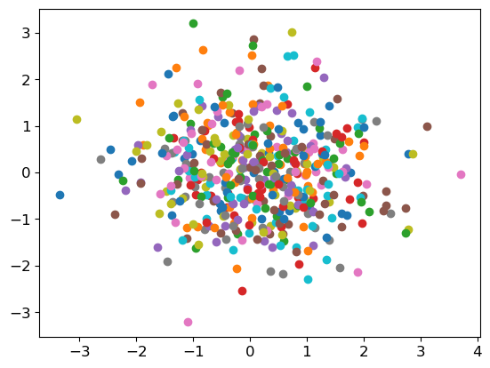

```python
# Sample from q(Z|x)
N = 500
Z = torch.zeros(N, z_dim)
_, ax = plt.subplots()
with torch.no_grad():
    for i in range(N):
        Z[i], _, _ = vae.encode(x0)
        ax.scatter(*Z[i].cpu().numpy())

# Should be close to the mu/sigma in the previous block above
print('sampled mu', torch.mean(Z, dim=0))
print('sampled sigma2', torch.var(Z, dim=0))
```

Let's now implement the full VAE Decoder, $\Psi _{\bb{\beta}}(\bb{z})$. It will work as follows:

1. Produce a feature vector $\tilde{\vec{h}}$ from the latent vector $\vec{z}$ using an affine transform.
2. Reconstruct an image $\tilde{\vec{x}}$ from $\tilde{\vec{h}}$ using the decoder CNN.

**TODO**: Implement the `decode()` method in the `VAE` class within the `hw3/autoencoder.py` module. You'll also need to define your parameters in `__init__()`. You may need to also re-run the block above after you implement this.

```python
x0r = vae.decode(z)

test.assertSequenceEqual(x0r.shape, x0.shape)
```

Our model's `forward()` function will simply return `decode(encode(x))` as well as the calculated mean and log-variance of the posterior.

```python
x0r, mu, log_sigma2 = vae(x0)

test.assertSequenceEqual(x0r.shape, x0.shape)
test.assertSequenceEqual(mu.shape, (1, z_dim))
test.assertSequenceEqual(log_sigma2.shape, (1, z_dim))
T.functional.to_pil_image(x0r[0].detach().cpu())
```

[output not shown]

### Loss Implementation

In practice, since we're using SGD, we'll drop the expectation over $\bb{X}$ and instead sample an instance from the training set and compute a point-wise loss. Similarly, we'll drop the expectation over $\bb{Z}$ by sampling from $q_{\vec{\alpha}}(\bb{Z}|\bb{x})$. Additionally, because the KL divergence is between two Gaussian distributions, there is a closed-form expression for it. These points bring us to the following point-wise loss:

$$ \ell(\vec{\alpha},\vec{\beta};\bb{x}) = \frac{1}{\sigma^2 d_x} \left\| \bb{x}- \Psi _{\bb{\beta}}\left( \bb{\mu} _{\bb{\alpha}}(\bb{x}) + \bb{\Sigma}^{\frac{1}{2}} _{\bb{\alpha}}(\bb{x}) \bb{u} \right) \right\| _2^2 + \mathrm{tr}\,\bb{\Sigma} _{\bb{\alpha}}(\bb{x}) + \|\bb{\mu} _{\bb{\alpha}}(\bb{x})\|^2 _2 - d_z - \log\det \bb{\Sigma} _{\bb{\alpha}}(\bb{x}), $$

where $d_z$ is the dimension of the latent space, $d_x$ is the dimension of the input and $\bb{u}\sim\mathcal{N}(\bb{0},\bb{I})$. This pointwise loss is the quantity that we'll compute and minimize with gradient descent. The first term corresponds to the data-reconstruction loss, while the second term corresponds to the KL-divergence loss. Note that the scaling by $d_x$ is not derived from the original loss formula and was added directly to the pointwise loss just to normalize the data term.

**TODO**: Implement the `vae_loss()` function in the `hw3/autoencoder.py` module.

```python
from hw3.autoencoder import vae_loss
torch.manual_seed(42)

def test_vae_loss():
    # Test data
    N, C, H, W = 10, 3, 64, 64
    z_dim = 32
    x  = torch.randn(N, C, H, W)*2 - 1
    xr = torch.randn(N, C, H, W)*2 - 1
    z_mu = torch.randn(N, z_dim)
    z_log_sigma2 = torch.randn(N, z_dim)
    x_sigma2 = 0.9

    loss, _, _ = vae_loss(x, xr, z_mu, z_log_sigma2, x_sigma2)

    test.assertAlmostEqual(loss.item(), 58.3234367, delta=1e-3)
    return loss

test_vae_loss()
```

```
tensor(58.3234)
```

### Sampling

The main advantage of a VAE is that it can by used as a generative model by sampling the latent space, since we optimize for a isotropic Gaussian prior $p(\bb{Z})$ in the loss function. Let's now implement this so that we can visualize how our model is doing when we train.

**TODO**: Implement the `sample()` method in the `VAE` class within the `hw3/autoencoder.py` module.

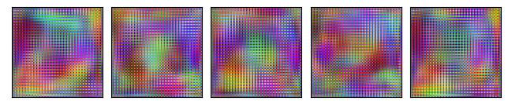

```python
samples = vae.sample(5)
_ = plot.tensors_as_images(samples)
```

### Training

Time to train!

**TODO**:

1. Implement the `VAETrainer` class in the `hw3/training.py` module. Make sure to implement the `checkpoints` feature of the `Trainer` class if you haven't done so already in Part 1.
2. Tweak the hyperparameters in the `part2_vae_hyperparams()` function within the `hw3/answers.py` module.

```python
import torch.optim as optim
from torch.utils.data import random_split
from torch.utils.data import DataLoader
from torch.nn import DataParallel
from hw3.training import VAETrainer
from hw3.answers import part2_vae_hyperparams

torch.manual_seed(42)

# Hyperparams
hp = part2_vae_hyperparams()
batch_size = hp['batch_size']
h_dim = hp['h_dim']
z_dim = hp['z_dim']
x_sigma2 = hp['x_sigma2']
learn_rate = hp['learn_rate']
betas = hp['betas']

# Data
split_lengths = [int(len(ds_gwb)*0.9), int(len(ds_gwb)*0.1)]
ds_train, ds_test = random_split(ds_gwb, split_lengths)
dl_train = DataLoader(ds_train, batch_size, shuffle=True)
dl_test  = DataLoader(ds_test,  batch_size, shuffle=True)
im_size = ds_train[0][0].shape

# Model
encoder = autoencoder.EncoderCNN(in_channels=im_size[0], out_channels=h_dim)
decoder = autoencoder.DecoderCNN(in_channels=h_dim, out_channels=im_size[0])
vae = autoencoder.VAE(encoder, decoder, im_size, z_dim)
vae_dp = DataParallel(vae).to(device)

# Optimizer
optimizer = optim.Adam(vae.parameters(), lr=learn_rate, betas=betas)

# Loss
def loss_fn(x, xr, z_mu, z_log_sigma2):
    return autoencoder.vae_loss(x, xr, z_mu, z_log_sigma2, x_sigma2)

# Trainer
trainer = VAETrainer(vae_dp, loss_fn, optimizer, device)
checkpoint_file = 'checkpoints/vae'
checkpoint_file_final = f'{checkpoint_file}_final'
if os.path.isfile(f'{checkpoint_file}.pt'):
    os.remove(f'{checkpoint_file}.pt')

# Show model and hypers
print(vae)
print(hp)
```

```
VAE(
  (features_encoder): EncoderCNN(
    (cnn): Sequential(
      (0): Conv2d(3, 64, kernel_size=(5, 5), stride=(1, 1), padding=(2, 2), bias=False)
      (1): MaxPool2d(kernel_size=2, stride=2, padding=0, dilation=1, ceil_mode=False)
      (2): BatchNorm2d(64, eps=1e-05, momentum=0.1, affine=True, track_running_stats=True)
      (3): GELU()
      (4): Conv2d(64, 128, kernel_size=(5, 5), stride=(1, 1), padding=(2, 2), bias=False)
      (5): MaxPool2d(kernel_size=2, stride=2, padding=0, dilation=1, ceil_mode=False)
      (6): BatchNorm2d(128, eps=1e-05, momentum=0.1, affine=True, track_running_stats=True)
      (7): GELU()
      (8): Conv2d(128, 256, kernel_size=(5, 5), stride=(1, 1), padding=(2, 2), bias=False)
      (9): MaxPool2d(kernel_size=2, stride=2, padding=0, dilation=1, ceil_mode=False)
      (10): BatchNorm2d(256, eps=1e-05, momentum=0.1, affine=True, track_running_stats=True)
      (11): GELU()
      (12): Conv2d(256, 800, kernel_size=(5, 5), stride=(1, 1), padding=(2, 2), bias=False)
      (13): MaxPool2d(kernel_size=2, stride=2, padding=0, dilation=1, ceil_mode=False)
      (14): BatchNorm2d(800, eps=1e-05, momentum=0.1, affine=True, track_running_stats=True)
      (15): GELU()
    )
  )
  (features_decoder): DecoderCNN(
    (cnn): Sequential(
      (0): ConvTranspose2d(800, 256, kernel_size=(5, 5), stride=(1, 1), padding=(2, 2), bias=False)
      (1): UpsamplingBilinear2d(scale_factor=2.0, mode=bilinear)
      (2): BatchNorm2d(256, eps=1e-05, momentum=0.1, affine=True, track_running_stats=True)
      (3): GELU()
      (4): ConvTranspose2d(256, 128, kernel_size=(5, 5), stride=(1, 1), padding=(2, 2), bias=False)
      (5): UpsamplingBilinear2d(scale_factor=2.0, mode=bilinear)
      (6): BatchNorm2d(128, eps=1e-05, momentum=0.1, affine=True, track_running_stats=True)
      (7): GELU()
      (8): ConvTranspose2d(128, 32, kernel_size=(5, 5), stride=(1, 1), padding=(2, 2), bias=False)
      (9): UpsamplingBilinear2d(scale_factor=2.0, mode=bilinear)
      (10): BatchNorm2d(32, eps=1e-05, momentum=0.1, affine=True, track_running_stats=True)
      (11): GELU()
      (12): ConvTranspose2d(32, 3, kernel_size=(5, 5), stride=(2, 2), padding=(2, 2), output_padding=(1, 1), bias=False)
    )
  )
  (mu_layer): Linear(in_features=12800, out_features=35, bias=True)
  (sigma_layer): Linear(in_features=12800, out_features=35, bias=True)
  (decoder_fc): Linear(in_features=35, out_features=12800, bias=True)
)
{'batch_size': 8, 'h_dim': 800, 'z_dim': 35, 'x_sigma2': 0.0015, 'learn_rate': 0.0002, 'betas': (0.99, 0.999)}
```

**TODO**:

1. Run the following block to train. It will sample some images from your model every few epochs so you can see the progress.
2. When you're satisfied with your results, rename the checkpoints file by adding `_final`. When you run the `main.py` script to generate your submission, the final checkpoints file will be loaded instead of running training. Note that your final submission zip will not include the `checkpoints/` folder. This is OK.

The images you get should be colorful, with different backgrounds and poses.

```
*** Loading final checkpoint file checkpoints/vae_final instead of training
*** Images Generated from best model:
```

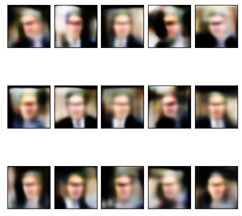

```python
import IPython.display

def post_epoch_fn(epoch, train_result, test_result, verbose):
    # Plot some samples if this is a verbose epoch
    if verbose:
        samples = vae.sample(n=5)
        fig, _ = plot.tensors_as_images(samples, figsize=(6,2))
        IPython.display.display(fig)
        plt.close(fig)

if os.path.isfile(f'{checkpoint_file_final}.pt'):
    print(f'*** Loading final checkpoint file {checkpoint_file_final} instead of training')
    checkpoint_file = checkpoint_file_final
else:
    res = trainer.fit(dl_train, dl_test,
                      num_epochs=200, early_stopping=20, print_every=1,
                      checkpoints=checkpoint_file,
                      post_epoch_fn=post_epoch_fn)

# Plot images from best model
saved_state = torch.load(f'{checkpoint_file}.pt', map_location=device)
vae_dp.load_state_dict(saved_state['model_state'])
print('*** Images Generated from best model:')
fig, _ = plot.tensors_as_images(vae_dp.module.sample(n=15), nrows=3, figsize=(6,6))
```

## Questions

**TODO** Answer the following questions. Write your answers in the appropriate variables in the module `hw3/answers.py`.

```python
from cs236781.answers import display_answer
import hw3.answers
```

### Question 1

What does the $\sigma^2$ hyperparameter (`x_sigma2` in the code) do? Explain the effect of low and high values.

```python
display_answer(hw3.answers.part2_q1)
```

**Your answer:** Sigma controls the amount of regularization in the VAE.

A small sigma makes the loss more dependant on the difference between the original and reconstructed image. A high sigma makes the loss more dependant on the kldiv loss, which encourages a smoother latent space. Therefore, a larger sigma will limit the variety of generated samples' difference from one another, and a smaller sigma will give us more variety but images will make less sense.

### Question 2

1. Explain the purpose of both parts of the VAE loss term - reconstruction loss and KL divergence loss.
2. How is the latent-space distribution affected by the KL loss term?
3. What's the benefit of this effect?

```python
display_answer(hw3.answers.part2_q2)
```

**Your answer:** **1** The reconstruction loss tries to create images which similar to the original given images, whereas KL divergence loss tries to make sure the tow images that are close on the latent space will reconstruct two similar images (smooth latent space).

**2** The latent-space variance and the KL loss are directly proportional. A smaller loss will minimize the variance of the latent space.

**3** The benefit of this effect is that a smoother latent space will help the model generate two similar reconstructions for\ two similar input images.

### Question 3

In the formulation of the VAE loss, why do we start by maximizing the evidence distribution, $p(\bb{X})$?

```python
display_answer(hw3.answers.part2_q3)
```

**Your answer:** The number of possible options for a 3x64x64 image is very high, and we want our generated image to be near the space of real-data images. Thus we need to increase the likelihood of generated images to be in the space of dataset images, In order to do so we maximize our evidence probability.

### Question 4

In the VAE encoder, why do we model the **log** of the latent-space variance corresponding to an input, $\bb{\sigma}^2_{\bb{\alpha}}$, instead of directly modelling this variance?

```python
display_answer(hw3.answers.part2_q4)
```

**Your answer:** We want to model the log of the variance instead of the variance directly, because we need only positive numbers after using the exponent func on the result, therefore we want the variance to be positive which is achieved by using the log function. Note that ReLU can achieve this too, BUT it has few issues such as replacing negative values to 0, giving us the same result for 2 different negative inputs. Moreover, log function will give us smaller variance than ReLU, which will lead to better training stability.

```python
%matplotlib inline

import os
from cs236781.answers import display_answer
import hw3.answers

import torch
import torch.nn as nn
from torch.utils.data import DataLoader
from torchtext.data.utils import get_tokenizer
from torchtext.vocab import build_vocab_from_iterator
from torchtext.datasets import multi30k, Multi30k
import torchdata
import unittest


test = unittest.TestCase()
DEVICE = torch.device('cuda' if torch.cuda.is_available() else 'cpu')
print('Using device:', DEVICE)
EMB_SIZE = 512
DIM = 512
HEADS = 8
NUM_LAYERS = 3
BATCH_SIZE = 2048
EPOCHS = 20
```

[output not shown]

$$ \newcommand{\mat}[1]{\boldsymbol {#1}} \newcommand{\mattr}[1]{\boldsymbol {#1}^\top} \newcommand{\matinv}[1]{\boldsymbol {#1}^{-1}} \newcommand{\vec}[1]{\boldsymbol {#1}} \newcommand{\vectr}[1]{\boldsymbol {#1}^\top} \newcommand{\rvar}[1]{\mathrm {#1}} \newcommand{\rvec}[1]{\boldsymbol{\mathrm{#1}}} \newcommand{\diag}{\mathop{\mathrm {diag}}} \newcommand{\set}[1]{\mathbb {#1}} \newcommand{\norm}[1]{\left\lVert#1\right\rVert} \newcommand{\pderiv}[2]{\frac{\partial #1}{\partial #2}} \newcommand{\bm}[1]{{\bf #1}} \newcommand{\bb}[1]{\bm{\mathrm{#1}}} $$

# Part 3: Language Translation with nn.Transformer and torchtext

This part shows:

- How to train a translation model from scratch using Transformer.
- Use tochtext library to access [Multi30k](https://www.statmt.org/wmt16/multimodal-task.html#task1) dataset in order to train a German to English translation model.

## Data Sourcing and Processing

[Torchtext library](https://pytorch.org/text/stable/) has utilities for creating datasets that can be easily iterated through for the purposes of creating a language translation model. In this example, we show how to use torchtext's inbuilt datasets, tokenize a raw text sentence, build vocabulary, and numericalize tokens into tensor. We will use [Multi30k dataset from torchtext library](https://pytorch.org/text/stable/datasets.html#multi30k) that yields a pair of source-target raw sentences.

### Building the Vocabulary

Let's begin by building a vocabulary of tokens using an external tokenizer for english and german.

```python
multi30k.URL["train"] = "https://raw.githubusercontent.com/neychev/small_DL_repo/master/datasets/Multi30k/training.tar.gz"
multi30k.URL["valid"] = "https://raw.githubusercontent.com/neychev/small_DL_repo/master/datasets/Multi30k/validation.tar.gz"

SRC_LANGUAGE = 'de'
TGT_LANGUAGE = 'en'
language_index = {SRC_LANGUAGE: 0, TGT_LANGUAGE: 1}

# Place-holders
token_transform = {}
vocab_transform = {}

# Create source and target language tokenizer.
token_transform[TGT_LANGUAGE] = get_tokenizer('spacy', language='en_core_web_sm')
token_transform[SRC_LANGUAGE] = get_tokenizer('spacy', language='de_core_news_sm')

# helper function to yield list of tokens
def yield_tokens(data_iter, language):
    for data_sample in data_iter:
        yield token_transform[language](data_sample[language_index[language]])


# Define special symbols and indices
UNK_IDX, PAD_IDX, BOS_IDX, EOS_IDX = 0, 1, 2, 3
# Make sure the tokens are in order of their indices to properly insert them in vocab
special_symbols = ['<unk>', '<pad>', '<bos>', '<eos>']


for ln in [SRC_LANGUAGE, TGT_LANGUAGE]:
    # Training data Iterator
    train_iter = Multi30k(split='train', language_pair=(SRC_LANGUAGE, TGT_LANGUAGE))
    # Create torchtext's Vocab object
    vocab_transform[ln] = build_vocab_from_iterator(yield_tokens(train_iter, ln),
                                                    min_freq=1,
                                                    specials=special_symbols,
                                                    special_first=True)
    # Set UNK_IDX as the default index. This index is returned when the token is not found.
    # If not set, it throws RuntimeError when the queried token is not found in the Vocabulary.
    vocab_transform[ln].set_default_index(UNK_IDX)
```

[output not shown]

[output not shown]

```python
stoi_mapping = vocab_transform[SRC_LANGUAGE].get_stoi()
print (f"Size of src vocab: {len(vocab_transform[SRC_LANGUAGE])}")
print (f"Size of tgt vocab: {len(vocab_transform[TGT_LANGUAGE])}")
print (f"Index for src padding: {stoi_mapping[special_symbols[1]]}")
print (f"Index for start of sequence token: {stoi_mapping[special_symbols[2]]}")
print (f"Index for end of sequence token: {stoi_mapping[special_symbols[3]]}")
print(f"An example of tokenization into words of a sentence in the src language: {token_transform[SRC_LANGUAGE]('Eine Gruppe von Menschen steht vor einem Iglu .')}")
print(f"An example of tokenization into vocab indices of a sentence in the src language: {vocab_transform[SRC_LANGUAGE](token_transform[SRC_LANGUAGE]('Eine Gruppe von Menschen steht vor einem Iglu .'))}")
```

[output not shown]

### Question 1

Which tokenization are we using? Word tokenization, character tokenization, or subword tokenization (for example - [BPE](https://en.wikipedia.org/wiki/Byte_pair_encoding)).

Explain the drawbacks of the tokenization method we are using compared to others.

```python
display_answer(hw3.answers.part3_q1)
```

## Seq2Seq Network using Transformer

Transformer is a Seq2Seq model introduced in [“Attention is all you need”](https://papers.nips.cc/paper/2017/file/3f5ee243547dee91fbd053c1c4a845aa-Paper.pdf) paper for solving machine translation tasks. We will create a Seq2Seq network that uses Transformer to translate sentences from german to english. The architecture of the transformer is described in the image below:

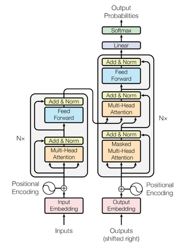

### Input Embedding and Positional Encoding

The first part is the embedding layer. This layer converts tensor of input indices into corresponding tensor of input embeddings. These embedding are further augmented with positional encodings to provide position information of input tokens to the model.

**TODO**:

- Implement the `PositionalEncoder` class in the `hw3/transformer.py` module.
- Run the following block.

```python
from hw3.transformer import  PositionalEncoder

positionalEncoder = PositionalEncoder(EMB_SIZE)
```

### Multi-Head Attention

Once we have our embedded values (with positional encodings), we can start building the layers of our model.

Here is an overview of the multi-headed attention layer:

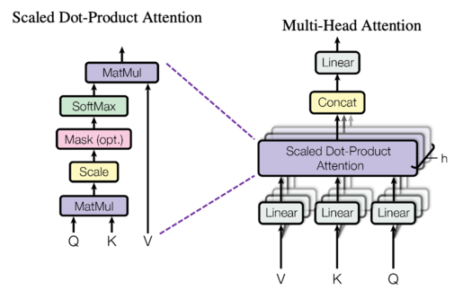

V, K and Q stand for ‘key’, ‘value’ and ‘query’. These are terms used in attention function. In the case of self attention, V, K and Q will simply be identical copies of the embedding vector (plus positional encoding). They will have the dimensions Batch_size *seq_len* dim.

In multi-head attention we split the embedding vector into N heads, so they will then have the dimensions batch_size *N* seq_len * (dim / N).

**TODO**:

- Implement the method `forward` of `MultiHeadAttention` class in the `hw3/transformer.py` module. Use the given function `attention` in `hw3/transformer.py`.
- Run the following block.

```python
from hw3.transformer import MultiHeadAttention

multiHeadAttention = MultiHeadAttention(HEADS, DIM)
```

### Mask

During training, we need a subsequent word mask that will prevent model to look into the future words when making predictions. We will also need masks to hide source and target padding tokens. Let's define a function that will take care of both.

In the encoder and decoder: The mask will zero attention outputs wherever there is just padding in the input sentences. In the decoder: To prevent the decoder ‘peaking’ ahead at the rest of the translated sentence when predicting the next word.

**TODO**:

- Implement the function `get_subsequent_mask` in the `hw3/transformer.py` module.

```python
from hw3.transformer import get_pad_mask, get_subsequent_mask
```

### Encoder and Decoder Layers

Let’s have another look at the over-all architecture and start building:

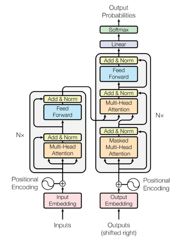

If you look at the diagram closely you can see a ‘Nx’ next to the encoder and decoder architectures. In reality, the encoder and decoder in the diagram above represent one layer of an encoder and one of the decoder. N is the variable for the number of layers there will be. We will now build a DecoderLayer modules with the architecture shown in the model above.

**TODO**:

- Implement the method `forward` of `DecoderLayer` class in the `hw3/transformer.py` module, similar to the class `EncoderLayer`. Use the given classes: `Norm` and `FeedForward` in `hw3/transformer.py`.
- Run the following block.

```python
from hw3.transformer import DecoderLayer, EncoderLayer

encoderLayer = EncoderLayer(DIM, HEADS)
decoderLayer = DecoderLayer(DIM, HEADS)
```

**TODO**:

- In a similar way, Implement the `Decoder` class in the `hw3/transformer.py` module.
- Run the following block.

```python
from hw3.transformer import Decoder, Encoder

encoder = Encoder(len(vocab_transform[SRC_LANGUAGE]), DIM, NUM_LAYERS, HEADS, PAD_IDX)
decoder = Decoder(len(vocab_transform[TGT_LANGUAGE]), DIM, NUM_LAYERS, HEADS, PAD_IDX)
```

### Transfomer

Now we can finish the implementation of the Transformer.

**TODO**:

- Implement the method `forward` of `Transformer` class in the `hw3/transformer.py` module.
- Run the following block.

```python
from hw3.transformer import Transformer

model = Transformer(len(vocab_transform[SRC_LANGUAGE]), len(vocab_transform[TGT_LANGUAGE]), DIM, NUM_LAYERS, HEADS, PAD_IDX)
```

## Training the Model

### Warm up

The learning rate warmup is an approach that uses a relatively small step size at the beginning of the training. The learning rate is increased linearly or non-linearly to a specific value in the first few epochs, and then shrinks to zero.

**TODO**:

- Implement the method `_get_lr_scale` of `ScheduledOptim` class in the `hw3/Optim.py` module.
- Run the following block.

### Train

With the transformer built, all that remains is to train it on the Multi30k dataset:

```python
import torch.optim as optim
from torch.nn.utils.rnn import pad_sequence
from hw3.Optim import ScheduledOptim
from hw3.transformerUtils import sequential_transforms, tensor_transform, train


text_transform = {}
for ln in [SRC_LANGUAGE, TGT_LANGUAGE]:
    text_transform[ln] = sequential_transforms(token_transform[ln], #Tokenization
                                               vocab_transform[ln], #Numericalization
                                               tensor_transform) # Add BOS/EOS and create tensor
# function to collate data samples into batch tesors
def collate_fn(batch):
    src_batch, tgt_batch = [], []
    for src_sample, tgt_sample in batch:
        src_batch.append(text_transform[SRC_LANGUAGE](src_sample.rstrip("\n")))
        tgt_batch.append(text_transform[TGT_LANGUAGE](tgt_sample.rstrip("\n")))

    src_batch = pad_sequence(src_batch, padding_value=PAD_IDX)
    tgt_batch = pad_sequence(tgt_batch, padding_value=PAD_IDX)
    return src_batch, tgt_batch

transformer = Transformer(
len(vocab_transform[SRC_LANGUAGE]), len(vocab_transform[TGT_LANGUAGE]), DIM, NUM_LAYERS, HEADS, PAD_IDX).to(DEVICE)

optimizer = ScheduledOptim(
optim.Adam(transformer.parameters(), betas=(0.9, 0.98), eps=1e-09),
2.0, DIM, 4000)

train_iter = Multi30k(split='train', language_pair=(SRC_LANGUAGE, TGT_LANGUAGE))
train_dataloader = DataLoader(train_iter, batch_size=BATCH_SIZE, collate_fn=collate_fn)
validation_iter = Multi30k(split='valid', language_pair=(SRC_LANGUAGE, TGT_LANGUAGE))
valid_dataloader = DataLoader(validation_iter, batch_size=BATCH_SIZE, collate_fn=collate_fn)

train(transformer, train_dataloader, valid_dataloader, optimizer, DEVICE, EPOCHS)
```

```
[Info] Training performance will be written to file: logs\train.log and logs\valid.log
[ Epoch 0 ]
```

[output not shown]

## Questions

**TODO** Answer the following questions. Write your answers in the appropriate variables in the module `hw3/answers.py`.

### Question 2

How many parameters your transformer has? how many if you exclude the embedings? Assume we have two tensors `X` and `Y` of shape `b,n,m` and `b,m,p`

```python
display_answer(hw3.answers.part3_q2)
```

[output not shown]

### Question 3

How can we use the architecture we built to translate documents efficiently memory-wise?

```python
display_answer(hw3.answers.part3_q3)
```

[output not shown]

### Question 4

what is the diffrance between using `torch.bmm(X,Y)` and `torch.matmul(X,Y)`?

```python
display_answer(hw3.answers.part3_q4)
```

[output not shown]